# Final Group Project - AirBnB Analytics - Istanbul

Group 17A

18/10/2020

# 1 Executive Summary

In this report, we analyze data about AirBnB listings and fit a model to predict the total cost for 2 people staying 4 nights in an AirBnB in Istanbul.

We download AirBnB data from insideairbnb.com, which was originally scraped from airbnb.com.

**Purpose:** 1. Perform a logical exploratory data analysis; 2. Select explanatory variables for regression purposes through plotting data; 3. Conduct a robust regression analysis with selected variables; 4. Figure out variables with collinearity and use shortlisted data sets for predictive and informative purposes; 5. Based on the analysis above, predict the total cost for 2 people spending 4 nights in Istanbul.

**Methodology:** 1. Use glimpse and skim functions to inspect the data features; 2. Take parsing exercises to make the data fit for purpose; 3. Employ insights from data through visualizations methods.

**Predictions:** From our regression analysis, we predict with a 95% level of confidence that the cost for 2 people of staying in an AirBnB in Istanbul for 4 nights would be approximately $821. However, we acknowledge that this is subject to the limitations of our analysis, including gaps in our data, subjectivity in selecting variables and the potentially skewing effect of the Covid-19 pandemic.

[output not shown]

[output not shown]

[output not shown]

[output not shown]

[output not shown]

```
## Rows: 23,728
## Columns: 106
## chr  [46]: listing_url, name, summary, space, description, experiences_offered, neighborho...
## dbl  [39]: id, scrape_id, host_id, host_listings_count, host_total_listings_count, latitud...
## lgl  [16]: thumbnail_url, medium_url, xl_picture_url, host_is_superhost, host_has_profile_...
## date [ 5]: last_scraped, host_since, calendar_last_scraped, first_review, last_review
##
## Pass a specification to the `col_types` argument to quiet this message
```

# 2 Exploratory Data Analysis

## 2.1 Inspect the data

First, we take a look at the data to get a sense of the variables and the variable types that are included in the data set.

```r
#glimpse the dataframe to get a sense of the raw data

glimpse(istanbul)
```

```
## Rows: 23,728
## Columns: 106
## $ id                                           <dbl> 4826, 20815, 27271, 28...
## $ listing_url                                  <chr> "https://www.airbnb.co...
## $ scrape_id                                    <dbl> 2.020063e+13, 2.020063...
## $ last_scraped                                 <date> 2020-06-28, 2020-06-2...
## $ name                                         <chr> "The Place", "The Bosp...
## $ summary                                      <chr> "My place is close to ...
## $ space                                        <chr> "A double bed apartmen...
## $ description                                  <chr> "My place is close to ...
## $ experiences_offered                          <chr> "none", "none", "none"...
## $ neighborhood_overview                        <chr> NA, "The lovely neighb...
## $ notes                                        <chr> NA, "The house may be ...
## $ transit                                      <chr> NA, "The city center, ...
## $ access                                       <chr> NA, "Our dear guests m...
```

[output cut: 93 more lines]

By taking a look at the raw data available on the AirBnB listings in Istanbul, we see that the dataframe is made up of 23,728 observations (rows) and 106 variables (columns). Notably, from the glimpse function above, we see that certain variables are stored with the incorrect data type, specifically we have quantitative variables (eg. price, cleaning_fee, extra_people) incorrectly stored as character variables and we will have to be converted into numeric data throughout the process.

```r
#skim for further inspection of the dataframe

skimr::skim(istanbul)
```

Data summary

| Name | istanbul |
| --- | --- |
| Number of rows | 23728 |
| Number of columns | 106 |
| _______________________ |  |
| Column type frequency: |  |
| character | 46 |
| Date | 5 |
| logical | 16 |
| numeric | 39 |
| ________________________ |  |
| Group variables | None |

**Variable type: character**

| skim_variable | n_missing | complete_rate | min | max | empty | n_unique | whitespace |
| --- | --- | --- | --- | --- | --- | --- | --- |
| listing_url | 0 | 1.00 | 33 | 37 | 0 | 23728 | 0 |
| name | 54 | 1.00 | 1 | 108 | 0 | 22685 | 0 |
| summary | 3779 | 0.84 | 1 | 1000 | 0 | 17202 | 1 |
| space | 11361 | 0.52 | 1 | 1000 | 0 | 10575 | 0 |
| description | 2876 | 0.88 | 1 | 1000 | 0 | 18952 | 0 |
| experiences_offered | 0 | 1.00 | 4 | 4 | 0 | 1 | 0 |
| neighborhood_overview | 12658 | 0.47 | 1 | 1000 | 0 | 8867 | 0 |
| notes | 18474 | 0.22 | 1 | 1000 | 0 | 4221 | 0 |
| transit | 13660 | 0.42 | 1 | 1000 | 0 | 8147 | 0 |
| access | 16337 | 0.31 | 1 | 1000 | 0 | 5943 | 0 |
| interaction | 15019 | 0.37 | 1 | 1000 | 0 | 6607 | 0 |
| house_rules | 16407 | 0.31 | 1 | 1000 | 0 | 6306 | 0 |
| picture_url | 0 | 1.00 | 80 | 146 | 0 | 22996 | 0 |
| host_url | 0 | 1.00 | 38 | 43 | 0 | 14450 | 0 |
| host_name | 1 | 1.00 | 1 | 35 | 0 | 4907 | 0 |
| host_location | 83 | 1.00 | 2 | 105 | 0 | 775 | 0 |
| host_about | 11902 | 0.50 | 1 | 5717 | 0 | 6144 | 10 |
| host_response_time | 1 | 1.00 | 3 | 18 | 0 | 5 | 0 |
| host_response_rate | 1 | 1.00 | 2 | 4 | 0 | 60 | 0 |
| host_acceptance_rate | 1 | 1.00 | 2 | 4 | 0 | 85 | 0 |
| host_thumbnail_url | 1 | 1.00 | 55 | 106 | 0 | 14358 | 0 |
| host_picture_url | 1 | 1.00 | 57 | 109 | 0 | 14358 | 0 |
| host_neighbourhood | 15027 | 0.37 | 4 | 33 | 0 | 59 | 0 |
| host_verifications | 0 | 1.00 | 2 | 158 | 0 | 277 | 0 |
| street | 0 | 1.00 | 10 | 116 | 0 | 1180 | 0 |
| neighbourhood | 5377 | 0.77 | 4 | 15 | 0 | 15 | 0 |
| neighbourhood_cleansed | 0 | 1.00 | 4 | 13 | 0 | 39 | 0 |
| city | 773 | 0.97 | 2 | 69 | 0 | 641 | 0 |
| state | 397 | 0.98 | 1 | 58 | 0 | 293 | 0 |
| zipcode | 2422 | 0.90 | 1 | 43 | 0 | 388 | 0 |
| market | 0 | 1.00 | 7 | 21 | 0 | 3 | 0 |
| smart_location | 0 | 1.00 | 6 | 77 | 0 | 706 | 0 |
| country_code | 0 | 1.00 | 2 | 2 | 0 | 3 | 0 |
| country | 0 | 1.00 | 6 | 12 | 0 | 3 | 0 |
| property_type | 0 | 1.00 | 3 | 22 | 0 | 43 | 0 |
| room_type | 0 | 1.00 | 10 | 15 | 0 | 4 | 0 |
| bed_type | 0 | 1.00 | 5 | 13 | 0 | 5 | 0 |
| amenities | 0 | 1.00 | 2 | 1297 | 0 | 21255 | 0 |
| price | 0 | 1.00 | 5 | 10 | 0 | 501 | 0 |
| weekly_price | 21993 | 0.07 | 6 | 10 | 0 | 581 | 0 |
| monthly_price | 22031 | 0.07 | 7 | 11 | 0 | 628 | 0 |
| security_deposit | 15623 | 0.34 | 5 | 10 | 0 | 357 | 0 |
| cleaning_fee | 13660 | 0.42 | 5 | 9 | 0 | 294 | 0 |
| extra_people | 0 | 1.00 | 5 | 9 | 0 | 215 | 0 |
| calendar_updated | 0 | 1.00 | 5 | 14 | 0 | 104 | 0 |
| cancellation_policy | 0 | 1.00 | 6 | 27 | 0 | 6 | 0 |

**Variable type: Date**

| skim_variable | n_missing | complete_rate | min | max | median | n_unique |
| --- | --- | --- | --- | --- | --- | --- |
| last_scraped | 0 | 1.00 | 2020-06-28 | 2020-06-30 | 2020-06-29 | 3 |
| host_since | 1 | 1.00 | 2009-01-14 | 2020-06-27 | 2017-08-27 | 3095 |
| calendar_last_scraped | 0 | 1.00 | 2020-06-28 | 2020-06-30 | 2020-06-29 | 3 |
| first_review | 12375 | 0.48 | 2009-06-01 | 2020-06-29 | 2019-04-12 | 2216 |
| last_review | 12375 | 0.48 | 2009-06-01 | 2020-06-29 | 2020-01-01 | 1424 |

**Variable type: logical**

| skim_variable | n_missing | complete_rate | mean | count |
| --- | --- | --- | --- | --- |
| thumbnail_url | 23728 | 0 | NaN | : |
| medium_url | 23728 | 0 | NaN | : |
| xl_picture_url | 23728 | 0 | NaN | : |
| host_is_superhost | 1 | 1 | 0.11 | FAL: 21147, TRU: 2580 |
| host_has_profile_pic | 1 | 1 | 1.00 | TRU: 23625, FAL: 102 |
| host_identity_verified | 1 | 1 | 0.16 | FAL: 19951, TRU: 3776 |
| neighbourhood_group_cleansed | 23728 | 0 | NaN | : |
| is_location_exact | 0 | 1 | 0.35 | FAL: 15329, TRU: 8399 |
| has_availability | 0 | 1 | 1.00 | TRU: 23728 |
| requires_license | 0 | 1 | 0.00 | FAL: 23728 |
| license | 23728 | 0 | NaN | : |
| jurisdiction_names | 23728 | 0 | NaN | : |
| instant_bookable | 0 | 1 | 0.60 | TRU: 14249, FAL: 9479 |
| is_business_travel_ready | 0 | 1 | 0.00 | FAL: 23728 |
| require_guest_profile_picture | 0 | 1 | 0.01 | FAL: 23571, TRU: 157 |
| require_guest_phone_verification | 0 | 1 | 0.01 | FAL: 23526, TRU: 202 |

**Variable type: numeric**

| skim_variable | n_missing | complete_rate | mean | sd | p0 | p25 | p50 | p75 | p100 | hist |
| --- | --- | --- | --- | --- | --- | --- | --- | --- | --- | --- |
| id | 0 | 1.00 | 2.913711e+07 | 13059641.35 | 4.826000e+03 | 2.101860e+07 | 3.398637e+07 | 3.965902e+07 | 4.397093e+07 | ▂▂▂▃▇ |
| scrape_id | 0 | 1.00 | 2.020063e+13 | 0.00 | 2.020063e+13 | 2.020063e+13 | 2.020063e+13 | 2.020063e+13 | 2.020063e+13 | ▁▁▇▁▁ |
| host_id | 0 | 1.00 | 1.493973e+08 | 115545247.88 | 6.603000e+03 | 3.285440e+07 | 1.477727e+08 | 2.588145e+08 | 3.522041e+08 | ▇▂▃▅▃ |
| host_listings_count | 1 | 1.00 | 2.433000e+01 | 223.97 | 0.000000e+00 | 1.000000e+00 | 1.000000e+00 | 4.000000e+00 | 3.767000e+03 | ▇▁▁▁▁ |
| host_total_listings_count | 1 | 1.00 | 2.433000e+01 | 223.97 | 0.000000e+00 | 1.000000e+00 | 1.000000e+00 | 4.000000e+00 | 3.767000e+03 | ▇▁▁▁▁ |
| latitude | 0 | 1.00 | 4.103000e+01 | 0.05 | 4.081000e+01 | 4.101000e+01 | 4.103000e+01 | 4.105000e+01 | 4.148000e+01 | ▁▇▁▁▁ |
| longitude | 0 | 1.00 | 2.898000e+01 | 0.13 | 2.802000e+01 | 2.897000e+01 | 2.898000e+01 | 2.902000e+01 | 2.991000e+01 | ▁▁▇▁▁ |
| accommodates | 0 | 1.00 | 3.210000e+00 | 2.25 | 1.000000e+00 | 2.000000e+00 | 2.000000e+00 | 4.000000e+00 | 1.600000e+01 | ▇▁▁▁▁ |
| bathrooms | 86 | 1.00 | 1.210000e+00 | 1.04 | 0.000000e+00 | 1.000000e+00 | 1.000000e+00 | 1.000000e+00 | 5.000000e+01 | ▇▁▁▁▁ |
| bedrooms | 173 | 0.99 | 1.390000e+00 | 1.44 | 0.000000e+00 | 1.000000e+00 | 1.000000e+00 | 2.000000e+00 | 5.000000e+01 | ▇▁▁▁▁ |
| beds | 698 | 0.97 | 2.050000e+00 | 2.04 | 0.000000e+00 | 1.000000e+00 | 1.000000e+00 | 2.000000e+00 | 7.700000e+01 | ▇▁▁▁▁ |
| square_feet | 23492 | 0.01 | 6.045300e+02 | 1213.27 | 0.000000e+00 | 7.000000e+01 | 5.380000e+02 | 8.070000e+02 | 1.738400e+04 | ▇▁▁▁▁ |
| guests_included | 0 | 1.00 | 1.400000e+00 | 1.09 | 1.000000e+00 | 1.000000e+00 | 1.000000e+00 | 1.000000e+00 | 1.600000e+01 | ▇▁▁▁▁ |
| minimum_nights | 0 | 1.00 | 4.530000e+00 | 27.61 | 1.000000e+00 | 1.000000e+00 | 1.000000e+00 | 3.000000e+00 | 1.125000e+03 | ▇▁▁▁▁ |
| maximum_nights | 0 | 1.00 | 9.134279e+04 | 13941170.34 | 1.000000e+00 | 6.000000e+01 | 1.125000e+03 | 1.125000e+03 | 2.147484e+09 | ▇▁▁▁▁ |
| minimum_minimum_nights | 0 | 1.00 | 4.410000e+00 | 26.83 | 1.000000e+00 | 1.000000e+00 | 1.000000e+00 | 2.000000e+00 | 1.125000e+03 | ▇▁▁▁▁ |
| maximum_minimum_nights | 0 | 1.00 | 4.710000e+00 | 28.64 | 1.000000e+00 | 1.000000e+00 | 1.000000e+00 | 3.000000e+00 | 1.125000e+03 | ▇▁▁▁▁ |
| minimum_maximum_nights | 0 | 1.00 | 9.282400e+02 | 9680.29 | 1.000000e+00 | 3.600000e+02 | 1.125000e+03 | 1.125000e+03 | 1.000000e+06 | ▇▁▁▁▁ |
| maximum_maximum_nights | 0 | 1.00 | 9.288300e+02 | 9680.28 | 1.000000e+00 | 3.600000e+02 | 1.125000e+03 | 1.125000e+03 | 1.000000e+06 | ▇▁▁▁▁ |
| minimum_nights_avg_ntm | 0 | 1.00 | 4.510000e+00 | 27.01 | 1.000000e+00 | 1.000000e+00 | 1.000000e+00 | 3.000000e+00 | 1.125000e+03 | ▇▁▁▁▁ |
| maximum_nights_avg_ntm | 0 | 1.00 | 9.286600e+02 | 9680.28 | 1.000000e+00 | 3.600000e+02 | 1.125000e+03 | 1.125000e+03 | 1.000000e+06 | ▇▁▁▁▁ |
| availability_30 | 0 | 1.00 | 2.209000e+01 | 12.13 | 0.000000e+00 | 1.700000e+01 | 2.900000e+01 | 3.000000e+01 | 3.000000e+01 | ▂▁▁▁▇ |
| availability_60 | 0 | 1.00 | 4.534000e+01 | 23.78 | 0.000000e+00 | 4.100000e+01 | 5.900000e+01 | 6.000000e+01 | 6.000000e+01 | ▂▁▁▁▇ |
| availability_90 | 0 | 1.00 | 6.899000e+01 | 35.13 | 0.000000e+00 | 6.600000e+01 | 8.900000e+01 | 9.000000e+01 | 9.000000e+01 | ▂▁▁▁▇ |
| availability_365 | 0 | 1.00 | 2.277100e+02 | 146.61 | 0.000000e+00 | 8.900000e+01 | 3.020000e+02 | 3.650000e+02 | 3.650000e+02 | ▃▂▂▁▇ |
| number_of_reviews | 0 | 1.00 | 7.870000e+00 | 23.23 | 0.000000e+00 | 0.000000e+00 | 0.000000e+00 | 4.000000e+00 | 3.450000e+02 | ▇▁▁▁▁ |
| number_of_reviews_ltm | 0 | 1.00 | 3.040000e+00 | 7.47 | 0.000000e+00 | 0.000000e+00 | 0.000000e+00 | 2.000000e+00 | 1.080000e+02 | ▇▁▁▁▁ |
| review_scores_rating | 12978 | 0.45 | 9.132000e+01 | 14.02 | 2.000000e+01 | 9.000000e+01 | 9.600000e+01 | 1.000000e+02 | 1.000000e+02 | ▁▁▁▁▇ |
| review_scores_accuracy | 12991 | 0.45 | 9.290000e+00 | 1.42 | 2.000000e+00 | 9.000000e+00 | 1.000000e+01 | 1.000000e+01 | 1.000000e+01 | ▁▁▁▁▇ |
| review_scores_cleanliness | 12988 | 0.45 | 9.060000e+00 | 1.51 | 2.000000e+00 | 9.000000e+00 | 1.000000e+01 | 1.000000e+01 | 1.000000e+01 | ▁▁▁▂▇ |
| review_scores_checkin | 12991 | 0.45 | 9.520000e+00 | 1.28 | 2.000000e+00 | 1.000000e+01 | 1.000000e+01 | 1.000000e+01 | 1.000000e+01 | ▁▁▁▁▇ |
| review_scores_communication | 12987 | 0.45 | 9.550000e+00 | 1.24 | 2.000000e+00 | 1.000000e+01 | 1.000000e+01 | 1.000000e+01 | 1.000000e+01 | ▁▁▁▁▇ |
| review_scores_location | 12991 | 0.45 | 9.440000e+00 | 1.23 | 2.000000e+00 | 9.000000e+00 | 1.000000e+01 | 1.000000e+01 | 1.000000e+01 | ▁▁▁▁▇ |
| review_scores_value | 12993 | 0.45 | 9.190000e+00 | 1.40 | 2.000000e+00 | 9.000000e+00 | 1.000000e+01 | 1.000000e+01 | 1.000000e+01 | ▁▁▁▁▇ |
| calculated_host_listings_count | 0 | 1.00 | 5.860000e+00 | 16.54 | 1.000000e+00 | 1.000000e+00 | 2.000000e+00 | 5.000000e+00 | 1.760000e+02 | ▇▁▁▁▁ |
| calculated_host_listings_count_entire_homes | 0 | 1.00 | 2.810000e+00 | 6.37 | 0.000000e+00 | 0.000000e+00 | 1.000000e+00 | 2.000000e+00 | 6.600000e+01 | ▇▁▁▁▁ |
| calculated_host_listings_count_private_rooms | 0 | 1.00 | 2.460000e+00 | 15.07 | 0.000000e+00 | 0.000000e+00 | 1.000000e+00 | 1.000000e+00 | 1.750000e+02 | ▇▁▁▁▁ |
| calculated_host_listings_count_shared_rooms | 0 | 1.00 | 9.000000e-02 | 0.60 | 0.000000e+00 | 0.000000e+00 | 0.000000e+00 | 0.000000e+00 | 1.100000e+01 | ▇▁▁▁▁ |
| reviews_per_month | 12375 | 0.48 | 7.100000e-01 | 0.90 | 1.000000e-02 | 1.300000e-01 | 3.300000e-01 | 9.500000e-01 | 9.200000e+00 | ▇▁▁▁▁ |

Similarly, the skim function suggests the presence of duplicates and missing values, which will have to be cleaned out.

## 2.2 Clean the data

Next, to make the size of the data more managable, we exclude from the dataframe the variables we deemed as not needed or improper for the purpose of our analysis.

```r
# Select the relevant variables for our analyses

istanbul_listings <- istanbul %>%

  select (id,
          listing_url,
          price,
          cleaning_fee,
          extra_people,
          property_type,
          room_type,
          number_of_reviews,
          review_scores_rating,
          latitude,
          longitude,
          is_location_exact,
          neighbourhood,
          neighbourhood_cleansed,
          neighbourhood_group_cleansed,
          bathrooms,
          bedrooms,
          beds,
          host_identity_verified,
          host_is_superhost,
          accommodates,
          cancellation_policy,
          minimum_nights,
          guests_included)

# Take a look at the chosen variables to observe missing values

skimr::skim(istanbul_listings)
```

Data summary

| Name | istanbul_listings |
| --- | --- |
| Number of rows | 23728 |
| Number of columns | 24 |
| _______________________ |  |
| Column type frequency: |  |
| character | 9 |
| logical | 4 |
| numeric | 11 |
| ________________________ |  |
| Group variables | None |

**Variable type: character**

| skim_variable | n_missing | complete_rate | min | max | empty | n_unique | whitespace |
| --- | --- | --- | --- | --- | --- | --- | --- |
| listing_url | 0 | 1.00 | 33 | 37 | 0 | 23728 | 0 |
| price | 0 | 1.00 | 5 | 10 | 0 | 501 | 0 |
| cleaning_fee | 13660 | 0.42 | 5 | 9 | 0 | 294 | 0 |
| extra_people | 0 | 1.00 | 5 | 9 | 0 | 215 | 0 |
| property_type | 0 | 1.00 | 3 | 22 | 0 | 43 | 0 |
| room_type | 0 | 1.00 | 10 | 15 | 0 | 4 | 0 |
| neighbourhood | 5377 | 0.77 | 4 | 15 | 0 | 15 | 0 |
| neighbourhood_cleansed | 0 | 1.00 | 4 | 13 | 0 | 39 | 0 |
| cancellation_policy | 0 | 1.00 | 6 | 27 | 0 | 6 | 0 |

**Variable type: logical**

| skim_variable | n_missing | complete_rate | mean | count |
| --- | --- | --- | --- | --- |
| is_location_exact | 0 | 1 | 0.35 | FAL: 15329, TRU: 8399 |
| neighbourhood_group_cleansed | 23728 | 0 | NaN | : |
| host_identity_verified | 1 | 1 | 0.16 | FAL: 19951, TRU: 3776 |
| host_is_superhost | 1 | 1 | 0.11 | FAL: 21147, TRU: 2580 |

**Variable type: numeric**

| skim_variable | n_missing | complete_rate | mean | sd | p0 | p25 | p50 | p75 | p100 | hist |
| --- | --- | --- | --- | --- | --- | --- | --- | --- | --- | --- |
| id | 0 | 1.00 | 29137114.23 | 13059641.35 | 4826.00 | 21018599.50 | 33986367.00 | 39659017.50 | 43970934.00 | ▂▂▂▃▇ |
| number_of_reviews | 0 | 1.00 | 7.87 | 23.23 | 0.00 | 0.00 | 0.00 | 4.00 | 345.00 | ▇▁▁▁▁ |
| review_scores_rating | 12978 | 0.45 | 91.32 | 14.02 | 20.00 | 90.00 | 96.00 | 100.00 | 100.00 | ▁▁▁▁▇ |
| latitude | 0 | 1.00 | 41.03 | 0.05 | 40.81 | 41.01 | 41.03 | 41.05 | 41.48 | ▁▇▁▁▁ |
| longitude | 0 | 1.00 | 28.98 | 0.13 | 28.02 | 28.97 | 28.98 | 29.02 | 29.91 | ▁▁▇▁▁ |
| bathrooms | 86 | 1.00 | 1.21 | 1.04 | 0.00 | 1.00 | 1.00 | 1.00 | 50.00 | ▇▁▁▁▁ |
| bedrooms | 173 | 0.99 | 1.39 | 1.44 | 0.00 | 1.00 | 1.00 | 2.00 | 50.00 | ▇▁▁▁▁ |
| beds | 698 | 0.97 | 2.05 | 2.04 | 0.00 | 1.00 | 1.00 | 2.00 | 77.00 | ▇▁▁▁▁ |
| accommodates | 0 | 1.00 | 3.21 | 2.25 | 1.00 | 2.00 | 2.00 | 4.00 | 16.00 | ▇▁▁▁▁ |
| minimum_nights | 0 | 1.00 | 4.53 | 27.61 | 1.00 | 1.00 | 1.00 | 3.00 | 1125.00 | ▇▁▁▁▁ |
| guests_included | 0 | 1.00 | 1.40 | 1.09 | 1.00 | 1.00 | 1.00 | 1.00 | 16.00 | ▇▁▁▁▁ |

## 2.3 Data wrangling

We proceed to convert the relevant data columns into numeric values.

```r
#turn prices, cleaning_fee and extra people into a numeric column, and remove the '$' and ','

istanbul_listings <- transform(
  istanbul_listings,
  price=as.numeric(sub("\\$","",sub(",","", price)), na.rm=TRUE),
  cleaning_fee=as.numeric(sub("\\$","", sub(",","", cleaning_fee)),na.rm=TRUE),
  extra_people=as.numeric(sub("\\$","", sub(",","", extra_people)),na.rm=TRUE))
```

Besides, we remove duplicated listings within id and missing values within price.

```r
istanbul_listings_cleaned <- istanbul_listings %>%

  #remove duplicate ids
  filter(duplicated(id) == FALSE) %>%

  #remove listings with missing price
  filter(is.na(price) == FALSE)
```

Next, we clean other variables using the same way.

```r
#create a new column with NAs replaced with 0s for cleaning_fee

istanbul_listings_cleaned <- istanbul_listings_cleaned %>%
  mutate(cleaning_fee_cleaned = case_when(is.na(cleaning_fee) ~ 0, TRUE ~ cleaning_fee))
```

```r
istanbul_listings_cleaned <- istanbul_listings_cleaned %>%
  mutate(
    neighbourhood_group_cleaned = case_when(

      #create variable that clusters neighbourhoods for further analysis
      neighbourhood_cleansed == "Arnavutkoy" ~ "European Side",
      neighbourhood_cleansed == "Avcilar" ~ "European Side",
      neighbourhood_cleansed == "Bagcilar" ~ "European Side",
      neighbourhood_cleansed == "Bagcilar" ~ "European Side",
      neighbourhood_cleansed == "Bahcelievler" ~ "European Side",
      neighbourhood_cleansed == "Bakirkoy" ~ "European Side",
      neighbourhood_cleansed == "Basaksehir" ~ "European Side",
      neighbourhood_cleansed == "Bayrampasa" ~ "European Side",
      neighbourhood_cleansed == "Besiktas" ~ "European Side",
      neighbourhood_cleansed == "Beylikduzu" ~ "European Side",
      neighbourhood_cleansed == "Beyoglu" ~ "European Side",
      neighbourhood_cleansed == "Buyukcekmece" ~ "European Side",
      neighbourhood_cleansed == "Catalca" ~ "European Side",
      neighbourhood_cleansed == "Esenler" ~ "European Side",
      neighbourhood_cleansed == "Esenyurt" ~ "European Side",
      neighbourhood_cleansed == "Eyup" ~ "European Side",
      neighbourhood_cleansed == "Fatih" ~ "European Side",
      neighbourhood_cleansed == "Gaziosmanpasa" ~ "European Side",
      neighbourhood_cleansed == "Gungoren" ~ "European Side",
      neighbourhood_cleansed == "Kagithane" ~ "European Side",
      neighbourhood_cleansed == "Kucukcekmece" ~ "European Side",
      neighbourhood_cleansed == "Sariyer" ~ "European Side",
      neighbourhood_cleansed == "Silivri" ~ "European Side",
      neighbourhood_cleansed == "Sultangazi" ~ "European Side",
      neighbourhood_cleansed == "Sisli" ~ "European Side",
      neighbourhood_cleansed == "Zeytinburnu" ~ "European Side",
      neighbourhood_cleansed == "Adalar" ~ "Asian Side",
      neighbourhood_cleansed == "Atasehir" ~ "Asian Side",
      neighbourhood_cleansed == "Beykoz" ~ "Asian Side",
      neighbourhood_cleansed == "Cekmekoy" ~ "Asian Side",
      neighbourhood_cleansed == "Kadikoy" ~ "Asian Side",
      neighbourhood_cleansed == "Kartal" ~ "Asian Side",
      neighbourhood_cleansed == "Maltepe" ~ "Asian Side",
      neighbourhood_cleansed == "Pendik" ~ "Asian Side",
      neighbourhood_cleansed == "Sancaktepe" ~ "Asian Side",
      neighbourhood_cleansed == "Sultanbeyli" ~ "Asian Side",
      neighbourhood_cleansed == "Sile" ~ "Asian Side",
      neighbourhood_cleansed == "Tuzla" ~ "Asian Side",
      neighbourhood_cleansed == "Umraniye" ~ "Asian Side",
      neighbourhood_cleansed == "Uskudar" ~ "Asian Side"))
```

```r
#create a new column with NAs replaced with 0s for extra_people

istanbul_listings_cleaned <- istanbul_listings_cleaned %>%
  mutate(extra_people_cleaned = case_when(is.na(extra_people) ~ 0, TRUE ~ extra_people))
```

```r
#adjust the property_type

istanbul_listings_cleaned <- istanbul_listings_cleaned %>%
  mutate(prop_type_simplified = case_when(property_type %in% c("Apartment",
                                                               "Condominium",
                                                               "Serviced apartment",
                                                               "House",
                                                               "Hostel")
                                          ~ property_type, TRUE ~ "Other" ))

#visualize the most common property types

istanbul_listings_cleaned %>%
  group_by(prop_type_simplified) %>%
  tally() %>%
  arrange(desc(n)) %>%
  rename("Property Type" = prop_type_simplified) %>%

#format the table for HTML

kbl(caption = "Property type of Airbnb listings in Istanbul") %>%
  kable_styling()
```

Property type of Airbnb listings in Istanbul

| Property Type | n |
| --- | --- |
| Apartment | 14958 |
| Other | 4727 |
| Serviced apartment | 1700 |
| House | 1564 |
| Condominium | 629 |
| Hostel | 150 |

For the variable bedrooms, we notice the unusual value of zero, as seen from the graph below. And we proceed to remove the missing values (NAs).

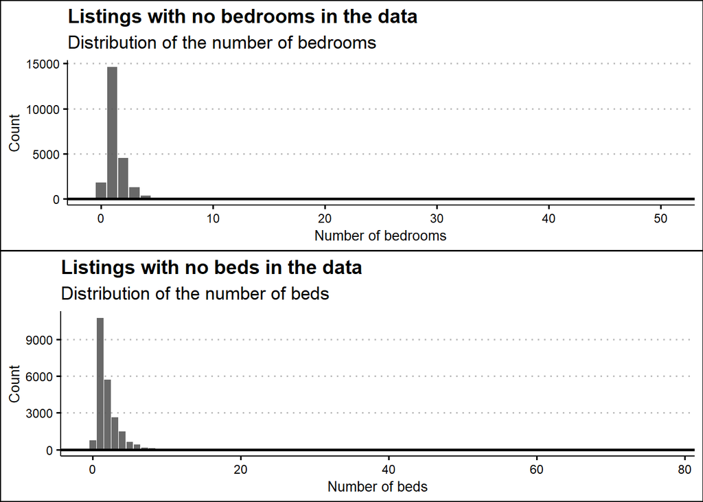

```r
#remove NAs

istanbul_listings_cleaned <- istanbul_listings_cleaned %>%
  filter(is.na(beds) == FALSE) %>%
  filter(is.na(bedrooms) == FALSE)

#plot histogram for price and price 4 nights

bedroom_plot <- istanbul_listings_cleaned %>%
  group_by(bedrooms) %>%
  tally() %>%
  ggplot() +
  geom_col(aes(x = bedrooms, y = n), alpha = 0.9) +
  geom_hline(aes(yintercept = 0), size = 1) +
  labs(title = "Listings with no bedrooms in the data",
       subtitle = "Distribution of the number of bedrooms",
       y = 'Count',
       x = 'Number of bedrooms') +
  theme_clean()

bed_plot <- istanbul_listings_cleaned %>%
  group_by(beds) %>%
  tally() %>%
  ggplot() +
  geom_col(aes(x = beds, y = n), alpha = 0.9) +
  geom_hline(aes(yintercept = 0), size = 1) +
  labs(title = "Listings with no beds in the data",
       subtitle = "Distribution of the number of beds",
       y = 'Count',
       x = 'Number of beds') +
  theme_clean()

grid.arrange(bedroom_plot, bed_plot, nrow = 2)
```

Next we inspect the neighborhoods and order them by number of listings.

```r
#inspect neighborhoods and ordering them by number of listings

istanbul_listings_cleaned %>% group_by(neighbourhood_group_cleaned) %>%
  tally() %>%
  arrange(desc(n)) %>%
  rename("Area"= neighbourhood_group_cleaned, "Total Listings" = n) %>%

#Format the table for HTML

kbl(caption = "Concentration of Airbnb Listings in Istanbul") %>%
  kable_styling()
```

Concentration of Airbnb Listings in Istanbul

| Area | Total Listings |
| --- | --- |
| European Side | 17848 |
| Asian Side | 5055 |

Some of the observations are also missing data points (NAs) for the variables host_is_identified and host_is_superhost, which we remove below.

```r
istanbul_listings_cleaned <- istanbul_listings_cleaned %>%

#remove NAs
  filter(is.na(host_is_superhost) == FALSE) %>%

  filter(is.na(host_identity_verified) == FALSE) %>%

  filter(is.na(review_scores_rating) == FALSE)
```

Given that we want to analyse a stay of 4 nights, we will filter out from the dataframe the listings that require a minimum of a 5 night stay.

```r
istanbul_listings_cleaned <- istanbul_listings_cleaned %>%

  #remove listings that do not require more than 4 nights
  filter(minimum_nights < 5)
```

We will also filter out data that only accommodates 1.

```r
istanbul_listings_cleaned <- istanbul_listings_cleaned %>%
  filter(accommodates > 1)
```

We update the dataframe by removing the now outdated columns, which have been cleaned above and compute accommodation cost for 4 nights for 2 people.

```r
istanbul_listings_final <- istanbul_listings_cleaned %>%

  #remove unwanted columns from the data frame
  select(-c(cleaning_fee,
            property_type,
            extra_people))

  #create a new column with the price for 4 nights for 2 people per listing
  istanbul_listings_final$price_4_nights =
    istanbul_listings_cleaned$price * 4 +
    istanbul_listings_cleaned$cleaning_fee_cleaned +
    istanbul_listings_cleaned$extra_people_clean
```

```r
#skim the updated dataframe

skim(istanbul_listings_final)
```

Data summary

| Name | istanbul_listings_final |
| --- | --- |
| Number of rows | 8738 |
| Number of columns | 26 |
| _______________________ |  |
| Column type frequency: |  |
| character | 7 |
| logical | 4 |
| numeric | 15 |
| ________________________ |  |
| Group variables | None |

**Variable type: character**

| skim_variable | n_missing | complete_rate | min | max | empty | n_unique | whitespace |
| --- | --- | --- | --- | --- | --- | --- | --- |
| listing_url | 0 | 1.00 | 33 | 37 | 0 | 8738 | 0 |
| room_type | 0 | 1.00 | 10 | 15 | 0 | 4 | 0 |
| neighbourhood | 1270 | 0.85 | 4 | 15 | 0 | 15 | 0 |
| neighbourhood_cleansed | 0 | 1.00 | 4 | 13 | 0 | 39 | 0 |
| cancellation_policy | 0 | 1.00 | 6 | 27 | 0 | 6 | 0 |
| neighbourhood_group_cleaned | 0 | 1.00 | 10 | 13 | 0 | 2 | 0 |
| prop_type_simplified | 0 | 1.00 | 5 | 18 | 0 | 6 | 0 |

**Variable type: logical**

| skim_variable | n_missing | complete_rate | mean | count |
| --- | --- | --- | --- | --- |
| is_location_exact | 0 | 1 | 0.41 | FAL: 5177, TRU: 3561 |
| neighbourhood_group_cleansed | 8738 | 0 | NaN | : |
| host_identity_verified | 0 | 1 | 0.23 | FAL: 6741, TRU: 1997 |
| host_is_superhost | 0 | 1 | 0.22 | FAL: 6858, TRU: 1880 |

**Variable type: numeric**

| skim_variable | n_missing | complete_rate | mean | sd | p0 | p25 | p50 | p75 | p100 | hist |
| --- | --- | --- | --- | --- | --- | --- | --- | --- | --- | --- |
| id | 0 | 1 | 27108948.22 | 13054887.41 | 4826.00 | 17838744.50 | 31723061.00 | 37822812.50 | 43779043.00 | ▃▂▂▆▇ |
| price | 0 | 1 | 428.83 | 1769.53 | 0.00 | 171.00 | 267.00 | 439.00 | 76922.00 | ▇▁▁▁▁ |
| number_of_reviews | 0 | 1 | 18.87 | 33.94 | 0.00 | 2.00 | 6.00 | 20.00 | 345.00 | ▇▁▁▁▁ |
| review_scores_rating | 0 | 1 | 91.07 | 13.82 | 20.00 | 89.00 | 96.00 | 100.00 | 100.00 | ▁▁▁▁▇ |
| latitude | 0 | 1 | 41.03 | 0.04 | 40.81 | 41.01 | 41.03 | 41.04 | 41.48 | ▁▇▁▁▁ |
| longitude | 0 | 1 | 28.99 | 0.11 | 28.05 | 28.97 | 28.98 | 29.00 | 29.91 | ▁▁▇▁▁ |
| bathrooms | 6 | 1 | 1.20 | 0.97 | 0.00 | 1.00 | 1.00 | 1.00 | 50.00 | ▇▁▁▁▁ |
| bedrooms | 0 | 1 | 1.43 | 1.25 | 0.00 | 1.00 | 1.00 | 2.00 | 50.00 | ▇▁▁▁▁ |
| beds | 0 | 1 | 2.19 | 1.91 | 0.00 | 1.00 | 2.00 | 3.00 | 61.00 | ▇▁▁▁▁ |
| accommodates | 0 | 1 | 3.69 | 2.15 | 2.00 | 2.00 | 3.00 | 4.00 | 16.00 | ▇▂▁▁▁ |
| minimum_nights | 0 | 1 | 1.72 | 0.84 | 1.00 | 1.00 | 1.00 | 2.00 | 4.00 | ▇▅▁▂▁ |
| guests_included | 0 | 1 | 1.67 | 1.29 | 1.00 | 1.00 | 1.00 | 2.00 | 16.00 | ▇▁▁▁▁ |
| cleaning_fee_cleaned | 0 | 1 | 74.52 | 122.34 | 0.00 | 0.00 | 0.00 | 123.00 | 2115.00 | ▇▁▁▁▁ |
| extra_people_cleaned | 0 | 1 | 40.56 | 66.71 | 0.00 | 0.00 | 0.00 | 69.00 | 1800.00 | ▇▁▁▁▁ |
| price_4_nights | 0 | 1 | 1830.39 | 7087.61 | 29.00 | 737.00 | 1186.50 | 1888.50 | 307688.00 | ▇▁▁▁▁ |

## 2.4 Summary statistics

```r
summary(istanbul_listings_final)
```

```
##        id           listing_url            price          room_type
##  Min.   :    4826   Length:8738        Min.   :    0.0   Length:8738
##  1st Qu.:17838744   Class :character   1st Qu.:  171.0   Class :character
##  Median :31723061   Mode  :character   Median :  267.0   Mode  :character
##  Mean   :27108948                      Mean   :  428.8
##  3rd Qu.:37822812                      3rd Qu.:  439.0
##  Max.   :43779043                      Max.   :76922.0
##
##  number_of_reviews review_scores_rating    latitude       longitude
##  Min.   :  0.00    Min.   : 20.00       Min.   :40.81   Min.   :28.05
##  1st Qu.:  2.00    1st Qu.: 89.00       1st Qu.:41.01   1st Qu.:28.97
##  Median :  6.00    Median : 96.00       Median :41.03   Median :28.98
##  Mean   : 18.87    Mean   : 91.07       Mean   :41.03   Mean   :28.99
##  3rd Qu.: 20.00    3rd Qu.:100.00       3rd Qu.:41.04   3rd Qu.:29.00
##  Max.   :345.00    Max.   :100.00       Max.   :41.48   Max.   :29.91
##
##  is_location_exact neighbourhood      neighbourhood_cleansed
##  Mode :logical     Length:8738        Length:8738
##  FALSE:5177        Class :character   Class :character
##  TRUE :3561        Mode  :character   Mode  :character
##
##
##
##
##  neighbourhood_group_cleansed   bathrooms         bedrooms
##  Mode:logical                 Min.   : 0.000   Min.   : 0.000
##  NA's:8738                    1st Qu.: 1.000   1st Qu.: 1.000
##                               Median : 1.000   Median : 1.000
##                               Mean   : 1.196   Mean   : 1.428
##                               3rd Qu.: 1.000   3rd Qu.: 2.000
##                               Max.   :50.000   Max.   :50.000
##                               NA's   :6
##       beds        host_identity_verified host_is_superhost  accommodates
##  Min.   : 0.000   Mode :logical          Mode :logical     Min.   : 2.000
##  1st Qu.: 1.000   FALSE:6741             FALSE:6858        1st Qu.: 2.000
##  Median : 2.000   TRUE :1997             TRUE :1880        Median : 3.000
##  Mean   : 2.186                                            Mean   : 3.687
##  3rd Qu.: 3.000                                            3rd Qu.: 4.000
##  Max.   :61.000                                            Max.   :16.000
##
```

[output cut: 9 more lines]

```
##  Length:8738                 Min.   :   0.00      Length:8738
##  Class :character            1st Qu.:   0.00      Class :character
##  Mode  :character            Median :   0.00      Mode  :character
##                              Mean   :  40.56
##                              3rd Qu.:  69.00
##                              Max.   :1800.00
##
##  price_4_nights
##  Min.   :    29
##  1st Qu.:   737
##  Median :  1186
##  Mean   :  1830
##  3rd Qu.:  1888
##  Max.   :307688
##
```

From an initial overview of our summary statistics we extracted 5 main observations:

1.The price has a significantly higher mean than its median (428.8 and 267.0 respectively), suggesting the presence of outliers (particularly expensive listings) pushing the mean upward. 2.The number_of_reviews have an average of 18.87 reviews and a median of 6.00, but a maximum of 345.00, which is a surprisingly high number of reviews, likely an exception in our data, which also what pushed up the mean from the median. 3.The maximum cleaning_fee is of $2115, which is significantly greater that the average fee of 74.52, which will increase the overall price for that listing. 4.Unsurprisingly, price_4_nights have a higher variation than price, as this is a combination of several charges. 5.Comparing the 75th percentile with the maximum value for our variables we note that both beds and guests_included have an outlier. Moreover, it is unusual how guests_included go up to 16 but beds actually goes up to 61.

```r
#run favstats on some interesting variable combinations and keep the most interesting ones

favstats(price ~ accommodates, data=istanbul_listings_final)
```

| accommodates | min | Q1 | median | Q3 | max | mean | sd | n | missing |
| --- | --- | --- | --- | --- | --- | --- | --- | --- | --- |
| 2 | 14 | 123 | 192 | 274 | 7.69e+04 | 355 | 2.49e+03 | 3364 | 0 |
| 3 | 41 | 178 | 261 | 377 | 3.85e+03 | 312 | 269 | 1484 | 0 |
| 4 | 0 | 204 | 309 | 459 | 9.2e+03 | 381 | 386 | 1880 | 0 |
| 5 | 55 | 267 | 377 | 549 | 6e+03 | 470 | 404 | 701 | 0 |
| 6 | 0 | 309 | 476 | 693 | 6.85e+04 | 701 | 2.74e+03 | 636 | 0 |
| 7 | 82 | 384 | 555 | 768 | 5.88e+03 | 655 | 507 | 205 | 0 |
| 8 | 48 | 425 | 617 | 925 | 5.14e+03 | 743 | 590 | 191 | 0 |
| 9 | 69 | 438 | 775 | 1.06e+03 | 2e+03 | 832 | 475 | 43 | 0 |
| 10 | 62 | 473 | 857 | 1.2e+03 | 3.99e+03 | 955 | 686 | 91 | 0 |
| 11 | 336 | 586 | 926 | 1.37e+03 | 2.12e+03 | 1.04e+03 | 538 | 27 | 0 |
| 12 | 75 | 480 | 960 | 1.38e+03 | 3e+03 | 1.02e+03 | 707 | 37 | 0 |
| 13 | 507 | 780 | 1.16e+03 | 1.37e+03 | 3.54e+03 | 1.29e+03 | 811 | 12 | 0 |
| 14 | 151 | 535 | 1.58e+03 | 2.77e+03 | 6.17e+03 | 2.11e+03 | 2.02e+03 | 11 | 0 |
| 15 | 123 | 245 | 405 | 643 | 877 | 447 | 267 | 8 | 0 |
| 16 | 69 | 204 | 1.18e+03 | 2.63e+03 | 2.4e+04 | 1.91e+03 | 3.59e+03 | 48 | 0 |

```r
favstats(price ~ neighbourhood_cleansed, data=istanbul_listings_final)
```

| neighbourhood_cleansed | min | Q1 | median | Q3 | max | mean | sd | n | missing |
| --- | --- | --- | --- | --- | --- | --- | --- | --- | --- |
| Adalar | 69 | 244 | 350 | 603 | 2e+03 | 447 | 312 | 95 | 0 |
| Arnavutkoy | 96 | 134 | 199 | 264 | 1e+03 | 256 | 206 | 27 | 0 |
| Atasehir | 62 | 153 | 216 | 343 | 939 | 262 | 159 | 122 | 0 |
| Avcilar | 62 | 116 | 267 | 336 | 1.37e+03 | 266 | 216 | 47 | 0 |
| Bagcilar | 62 | 206 | 309 | 377 | 542 | 280 | 116 | 33 | 0 |
| Bahcelievler | 55 | 103 | 164 | 276 | 686 | 215 | 162 | 64 | 0 |
| Bakirkoy | 55 | 151 | 240 | 350 | 2.82e+03 | 358 | 412 | 81 | 0 |
| Basaksehir | 62 | 247 | 356 | 501 | 2.44e+03 | 446 | 383 | 57 | 0 |
| Bayrampasa | 69 | 69 | 103 | 274 | 1.03e+03 | 309 | 411 | 5 | 0 |
| Besiktas | 27 | 151 | 247 | 414 | 3.08e+03 | 357 | 356 | 555 | 0 |
| Beykoz | 41 | 103 | 199 | 1.05e+03 | 5.14e+03 | 742 | 1.11e+03 | 29 | 0 |
| Beylikduzu | 55 | 144 | 240 | 377 | 864 | 286 | 199 | 29 | 0 |
| Beyoglu | 0 | 192 | 302 | 475 | 2.4e+04 | 453 | 852 | 3376 | 0 |
| Buyukcekmece | 62 | 158 | 270 | 720 | 3.54e+03 | 631 | 816 | 24 | 0 |
| Catalca | 199 | 480 | 1e+03 | 2e+03 | 3.99e+03 | 1.53e+03 | 1.54e+03 | 5 | 0 |
| Cekmekoy | 82 | 151 | 161 | 190 | 302 | 176 | 64.5 | 8 | 0 |
| Esenler | 62 | 186 | 309 | 346 | 384 | 252 | 168 | 3 | 0 |
| Esenyurt | 55 | 144 | 199 | 302 | 1.95e+03 | 248 | 193 | 149 | 0 |
| Eyup | 62 | 101 | 212 | 358 | 1.15e+03 | 289 | 246 | 40 | 0 |
| Fatih | 55 | 192 | 309 | 459 | 7.69e+04 | 448 | 2.14e+03 | 1318 | 0 |
| Gaziosmanpasa | 62 | 112 | 268 | 352 | 651 | 264 | 164 | 20 | 0 |
| Gungoren | 41 | 89 | 165 | 247 | 1.41e+03 | 264 | 359 | 17 | 0 |
| Kadikoy | 48 | 110 | 192 | 298 | 1.23e+03 | 230 | 165 | 779 | 0 |
| Kagithane | 48 | 117 | 233 | 439 | 1.51e+03 | 332 | 291 | 129 | 0 |
| Kartal | 55 | 99.5 | 151 | 306 | 2.4e+03 | 324 | 463 | 35 | 0 |
| Kucukcekmece | 48 | 114 | 226 | 374 | 1.07e+03 | 284 | 235 | 31 | 0 |
| Maltepe | 62 | 103 | 171 | 233 | 1.45e+03 | 215 | 209 | 77 | 0 |
| Pendik | 55 | 103 | 158 | 247 | 3.85e+03 | 284 | 604 | 75 | 0 |
| Sancaktepe | 103 | 117 | 123 | 171 | 247 | 152 | 58.8 | 5 | 0 |
| Sariyer | 48 | 151 | 247 | 501 | 6.17e+03 | 586 | 1.04e+03 | 100 | 0 |
| Sile | 69 | 204 | 302 | 583 | 2.2e+03 | 432 | 351 | 56 | 0 |
| Silivri | 178 | 283 | 600 | 1.11e+03 | 2.74e+03 | 915 | 851 | 10 | 0 |
| Sisli | 14 | 165 | 302 | 480 | 6.86e+04 | 642 | 4.15e+03 | 1067 | 0 |
| Sultanbeyli | 130 | 130 | 130 | 130 | 130 | 130 | 0 | 2 | 0 |
| Sultangazi | 62 | 71.8 | 89 | 103 | 103 | 85.8 | 20.6 | 4 | 0 |
| Tuzla | 82 | 134 | 196 | 430 | 1.55e+03 | 361 | 389 | 20 | 0 |
| Umraniye | 55 | 130 | 148 | 247 | 501 | 193 | 107 | 30 | 0 |
| Uskudar | 48 | 103 | 185 | 375 | 2.8e+03 | 325 | 439 | 186 | 0 |
| Zeytinburnu | 48 | 192 | 267 | 389 | 1.31e+03 | 360 | 302 | 28 | 0 |

```r
favstats(price ~ host_is_superhost, data=istanbul_listings_final)
```

| host_is_superhost | min | Q1 | median | Q3 | max | mean | sd | n | missing |
| --- | --- | --- | --- | --- | --- | --- | --- | --- | --- |
| FALSE | 0 | 158 | 247 | 411 | 7.69e+04 | 400 | 1.38e+03 | 6858 | 0 |
| TRUE | 41 | 199 | 315 | 501 | 6.86e+04 | 535 | 2.75e+03 | 1880 | 0 |

```r
favstats(price ~ prop_type_simplified, data=istanbul_listings_final)
```

| prop_type_simplified | min | Q1 | median | Q3 | max | mean | sd | n | missing |
| --- | --- | --- | --- | --- | --- | --- | --- | --- | --- |
| Apartment | 0 | 158 | 267 | 439 | 6.86e+04 | 395 | 1.6e+03 | 5722 | 0 |
| Condominium | 55 | 144 | 261 | 446 | 2.31e+03 | 359 | 337 | 170 | 0 |
| Hostel | 69 | 89 | 117 | 192 | 850 | 156 | 121 | 53 | 0 |
| House | 55 | 151 | 247 | 436 | 2.4e+04 | 418 | 1.16e+03 | 472 | 0 |
| Other | 41 | 178 | 267 | 425 | 7.69e+04 | 522 | 2.14e+03 | 1617 | 0 |
| Serviced apartment | 48 | 199 | 309 | 501 | 6.61e+04 | 536 | 2.55e+03 | 704 | 0 |

```r
favstats(price ~ minimum_nights, data=istanbul_listings_final)
```

| minimum_nights | min | Q1 | median | Q3 | max | mean | sd | n | missing |
| --- | --- | --- | --- | --- | --- | --- | --- | --- | --- |
| 1 | 14 | 144 | 233 | 384 | 7.69e+04 | 399 | 1.7e+03 | 4394 | 0 |
| 2 | 0 | 192 | 302 | 459 | 6.86e+04 | 421 | 1.38e+03 | 2677 | 0 |
| 3 | 62 | 199 | 343 | 549 | 6.86e+04 | 547 | 2.62e+03 | 1383 | 0 |
| 4 | 41 | 204 | 306 | 480 | 2.53e+03 | 388 | 283 | 284 | 0 |

## 2.5 Correlation Matrix

From the summary and favstats investigations, we have decided to conduct further exploratory data analysis. We will first build a correlation martix to spot the relationships between the particular variables.

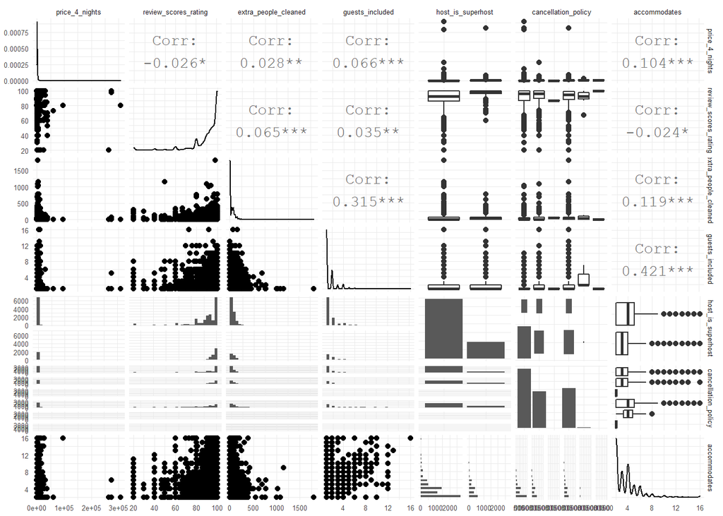

```r
istanbul_listings_final %>%
  select("price_4_nights",
                      "review_scores_rating",
                      "extra_people_cleaned",
                      "guests_included",
                      "host_is_superhost",
                      "cancellation_policy",
                      "accommodates") %>%
  ggpairs() +
  theme_minimal(base_size=6)
```

## 2.6 Informative visualizations

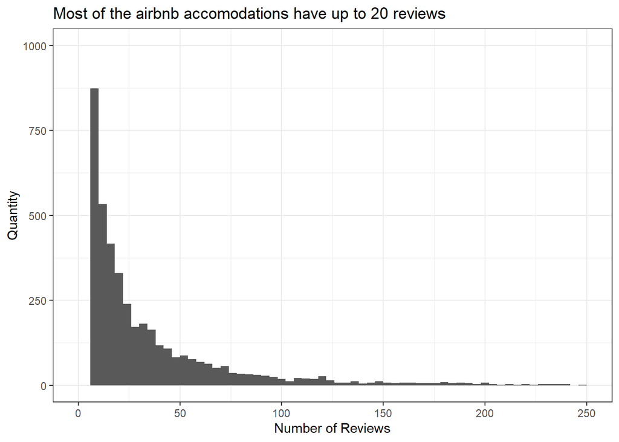

```r
ggplot(istanbul_listings_final,
       aes(x=number_of_reviews)) +
  geom_histogram(binwidth = 4) +
  xlim(0,250) +
  ylim(0,1000) +
  labs(title="Most of the airbnb accomodations have up to 20 reviews",
       x="Number of Reviews",
       y="Quantity") +
  theme_bw()
```

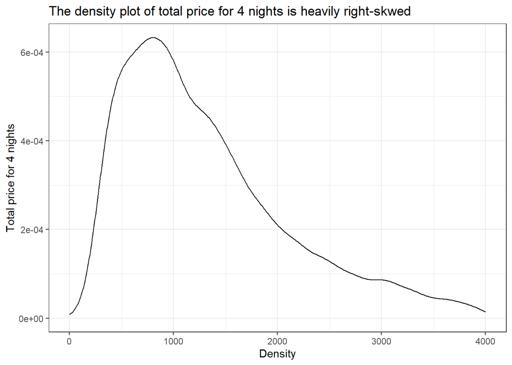

```r
#heavily right-skewed

ggplot(istanbul_listings_final,
       aes(x=price_4_nights)) +
  geom_density(bins=20) +
  xlim(0,4000) +
  labs(title="The density plot of total price for 4 nights is heavily right-skwed",
       x="Density",
       y="Total price for 4 nights") +
  theme_bw()
```

[figure not shown]

```r
#log also heavily right skewed

ggplot(istanbul_listings_final,
       aes(x=price_4_nights)) +
  geom_density(bins=20) +
  scale_x_log10() +
  xlim(0,2500) +
  labs(title="Logarithmic Total Price Shows Nature of Price Clusters",
       x="Density",
       y="Total price for 4 nights")+
  theme_bw()
```